# Časovne vrste - seminar

Poročilo o analizi časovnih vrst

Brina Pirc in Anja Trobec

Maj 2022

# DATOTEKA A

##### Narišite graf in komentirajte, ali se iz njega vidi kakšen trend ali sezonskost.

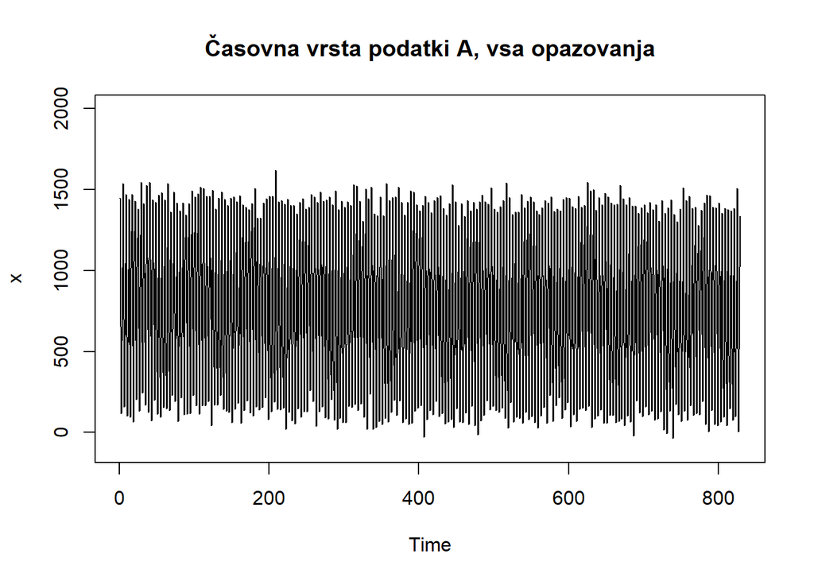

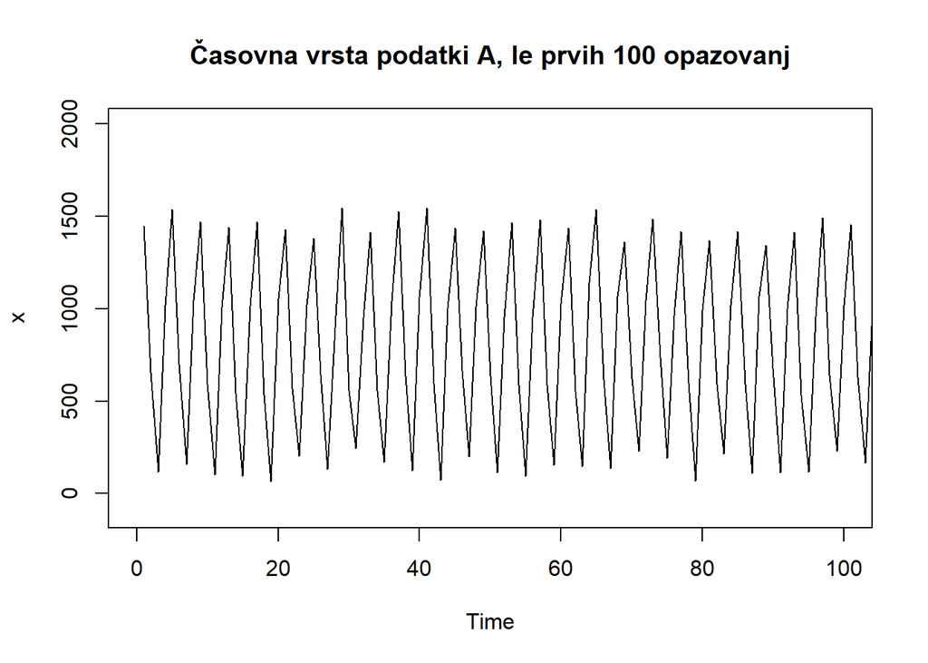

```
## [1] "Ne opazimo trenda, opazimo pa sezonskost."
```

##### Odstranite morebiten trend in sezonskost z metodami, uporabljenimi pri tečaju: (zaporedno) diferenciranje, logaritmiranje, neposredna ocena sezonskih komponent, polinomski trend stopnje največ 3 ali prileganje periodične funkcije (ali kakšna kombinacija teh metod). Potem ko odstranite morebiten trend, narišite tudi surovi in zglajeni periodogram ter komentirajte, ali se vidi kakšna sezonskost in kakšna naj bi bila perioda.

REŠEVANJE: logaritmiranja ne moremo uporabiti, ker imamo negativne podatke diferenciranje:

```
##
## Call:
## lm(formula = x ~ I(sin(p * t)) + I(cos(p * t)))
##
## Residuals:
##     Min      1Q  Median      3Q     Max
## -584.12 -145.73   -6.07  148.33  537.65
##
## Coefficients:
##               Estimate Std. Error t value Pr(>|t|)
## (Intercept)    770.830      7.615  101.22   <2e-16 ***
## I(sin(p * t))  286.654     10.770   26.62   <2e-16 ***
## I(cos(p * t))  549.648     10.770   51.04   <2e-16 ***
## ---
## Signif. codes:  0 '***' 0.001 '**' 0.01 '*' 0.05 '.' 0.1 ' ' 1
##
## Residual standard error: 219.3 on 826 degrees of freedom
## Multiple R-squared:  0.8004, Adjusted R-squared:    0.8
## F-statistic:  1657 on 2 and 826 DF,  p-value: < 2.2e-16
```

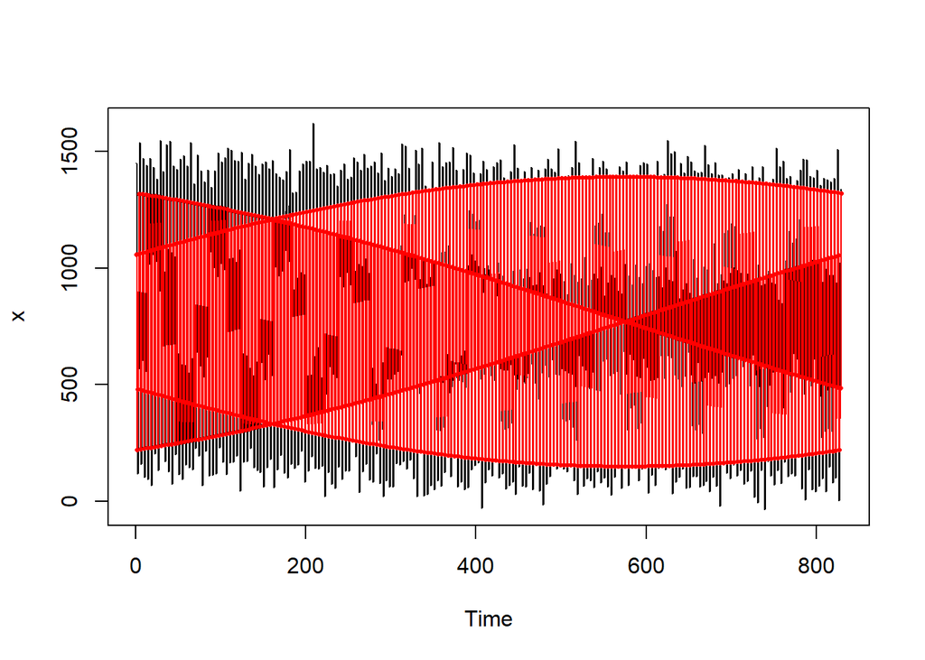

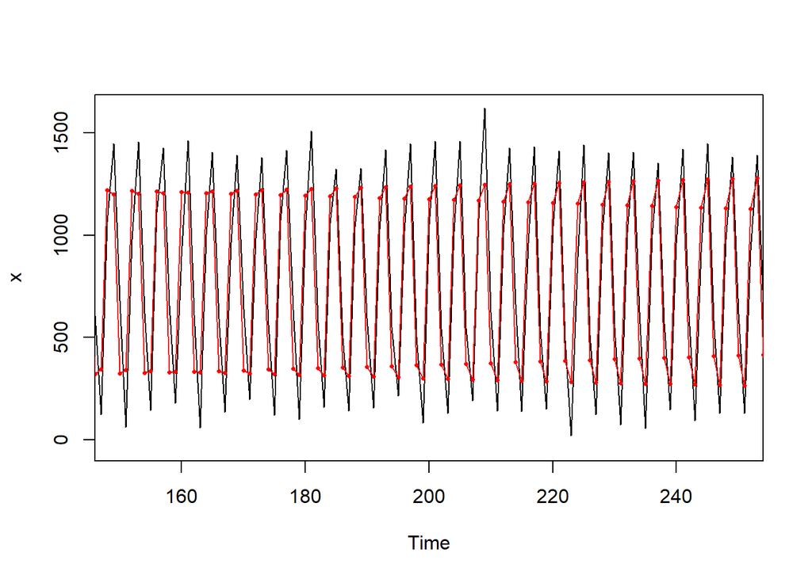

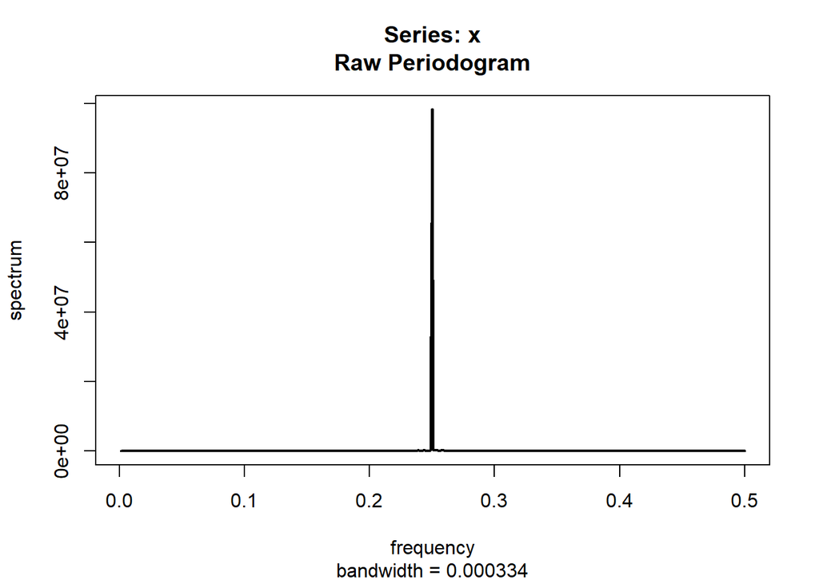

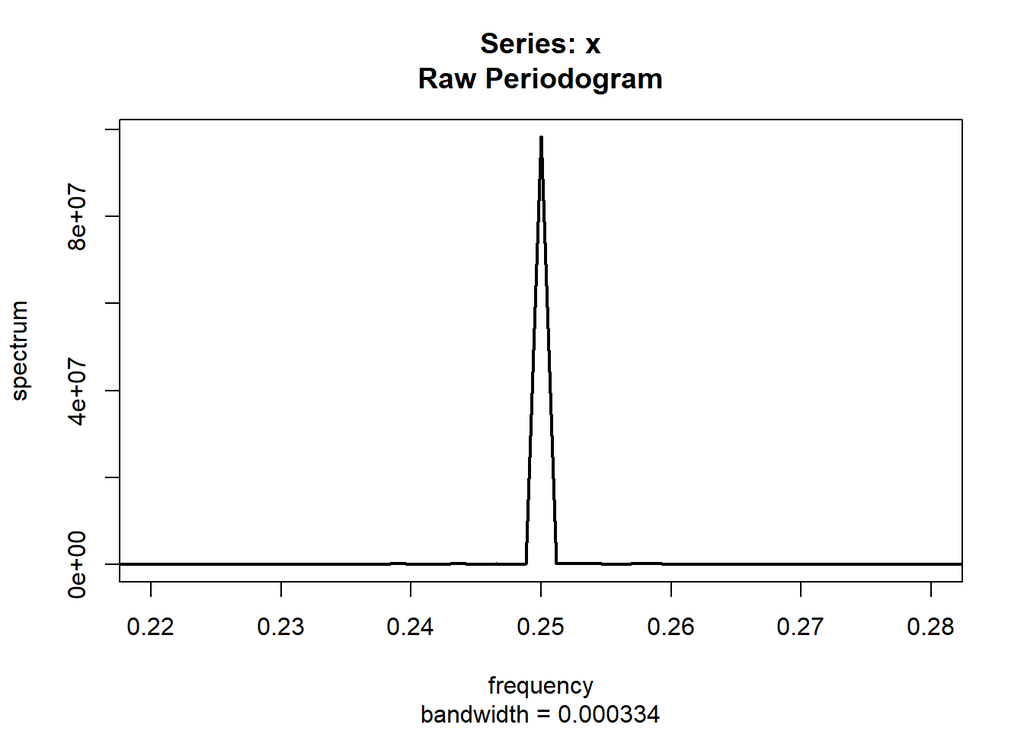

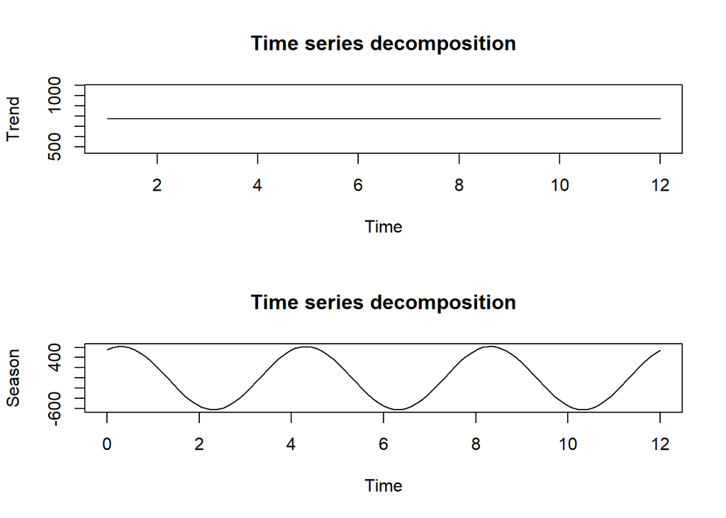

##### Narišite graf rezidualov in komentirajte, ali so videti stacionarni. Stacionarnost tudi preizkusite z uporabo ustreznih statističnih metod.

```
## [1] 0.799963
```

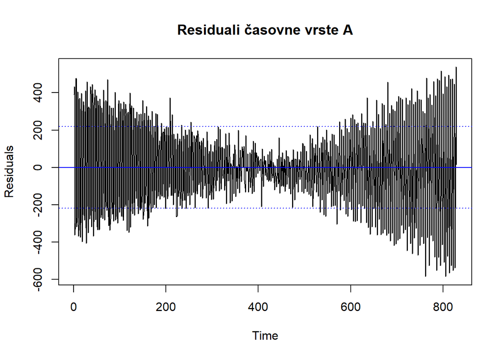

```
##
##  Augmented Dickey-Fuller Test
##
## data:  x.res
## Dickey-Fuller = -9.6012, Lag order = 9, p-value = 0.01
## alternative hypothesis: stationary
```

```
## [1] "Augmented Dickey-Fuller Test zavrne hipotezo o nestacionarnosti, torej imamo stacionarnost."
```

##### Na rezidualih naredite grafikona ACF in PACF in na njuni podlagi predlagajte vsaj en model vrste AR(p) ali MA(q).

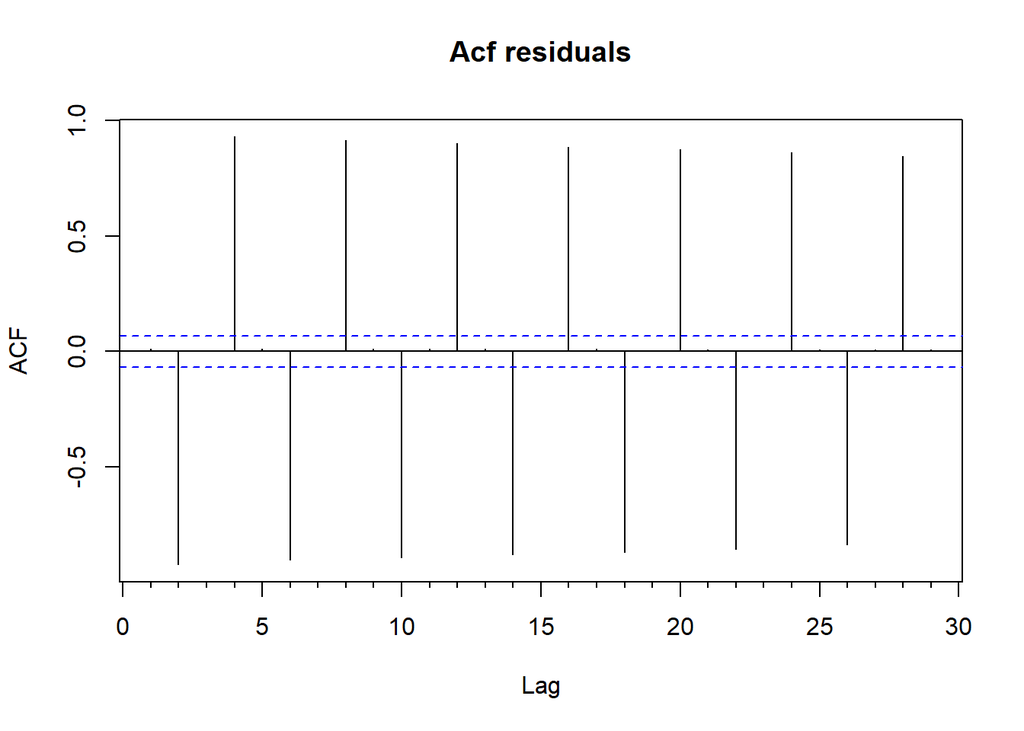

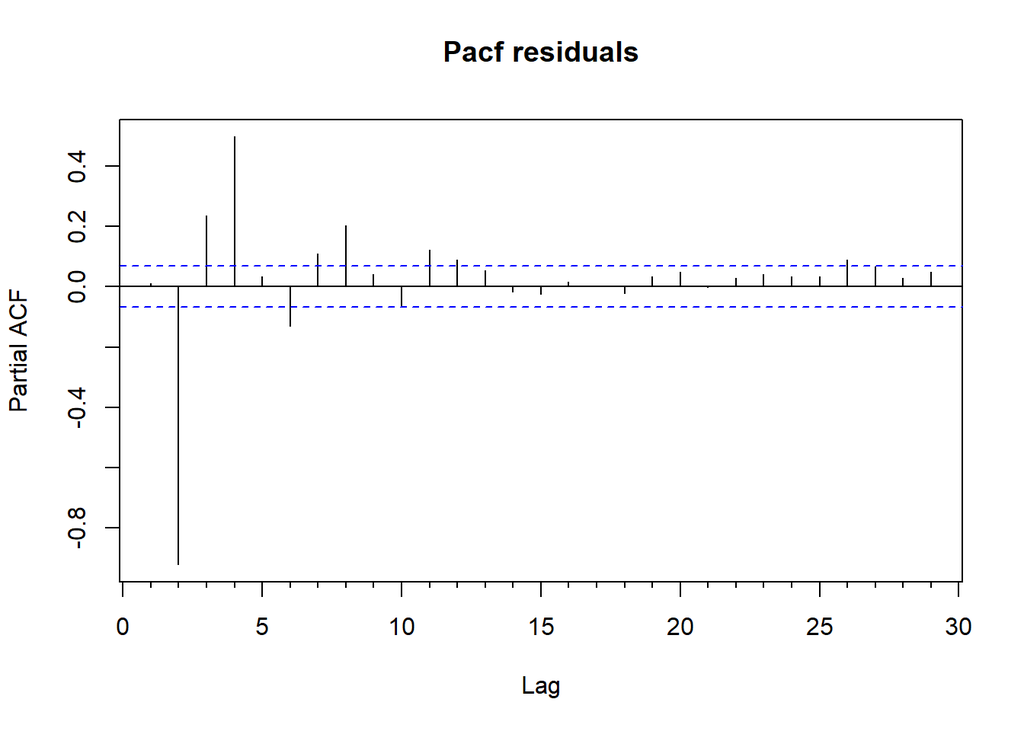

```
## [1] "Predlagava izbiro modela AR(4). V nadaljevanju pa bomo preverili ali gre morda za model ARMA."
```

##### Na podlagi Yule–Walkerjevih cenilk in kriterija AIC izberite najboljši model AR(p). Primerjajte ga z najboljšim modelom ARMA(p, q) za p + q ≤ 3 po kriteriju AIC (pozor: kriterij AIC je lahko definiran drugače od postopka do postopka). Če je videti smiselno, pa namesto tega uporabite model GARCH.

```
##
## Call:
## ar(x = x.res, aic = TRUE, arg = "yule–walker")
##
## Coefficients:
##       1        2        3        4        5        6        7        8
##  0.0872  -0.3776   0.0657   0.2923   0.0527  -0.0491   0.0633   0.1317
##       9       10       11       12       13
##  0.0700  -0.0434   0.1332   0.0847   0.0549
##
## Order selected 13  sigma^2 estimated as  4690
```

```
##
## Call:
## arima(x = x.res, order = c(0, 0, 1))
##
## Coefficients:
##          ma1  intercept
##       0.7939    -0.0458
## s.e.  0.0177    11.5541
##
## sigma^2 estimated as 34426:  log likelihood = -5506.89,  aic = 11019.79
```

[output not shown]

##### Izberite »optimalni« model in ocenite vse njegove parametre.

[output not shown]

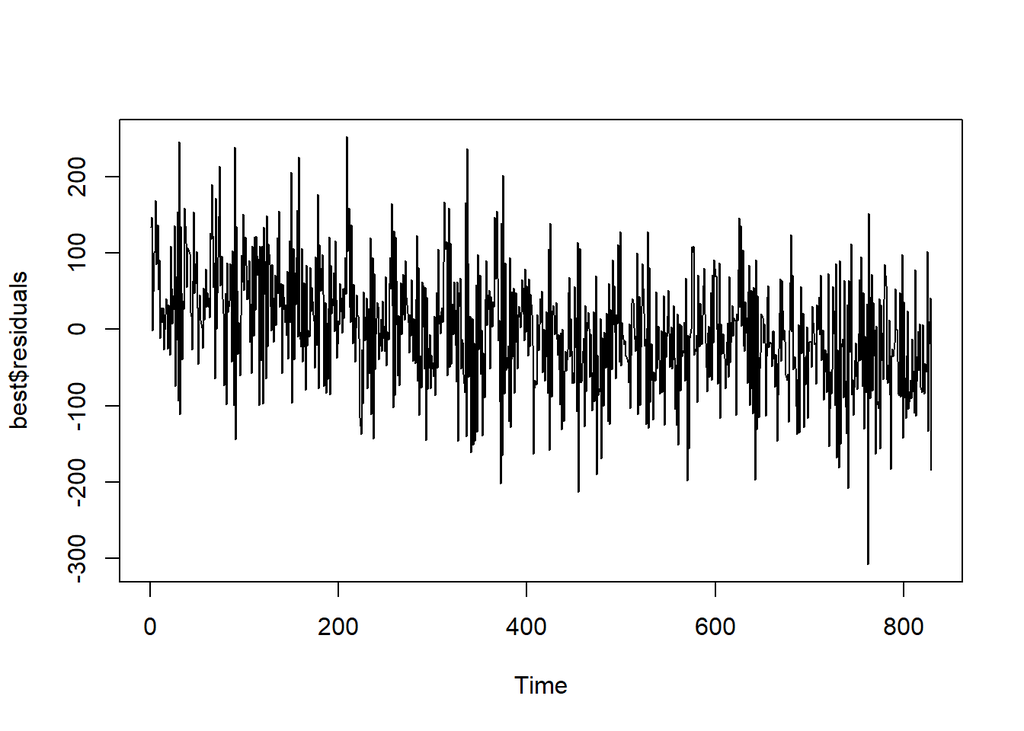

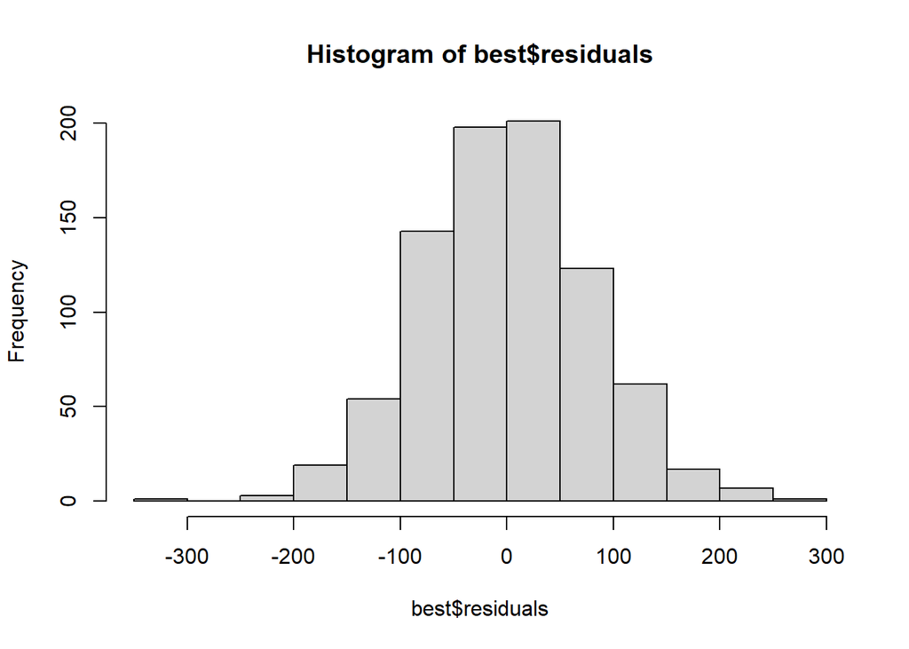

```
##
##  Shapiro-Wilk normality test
##
## data:  best$residuals
## W = 0.99837, p-value = 0.6376
```

```
## [1] "Shapirov test ne zavrne hipoteze, torej je porazdelitev značilno podobna normalni porazdelitvi."
```

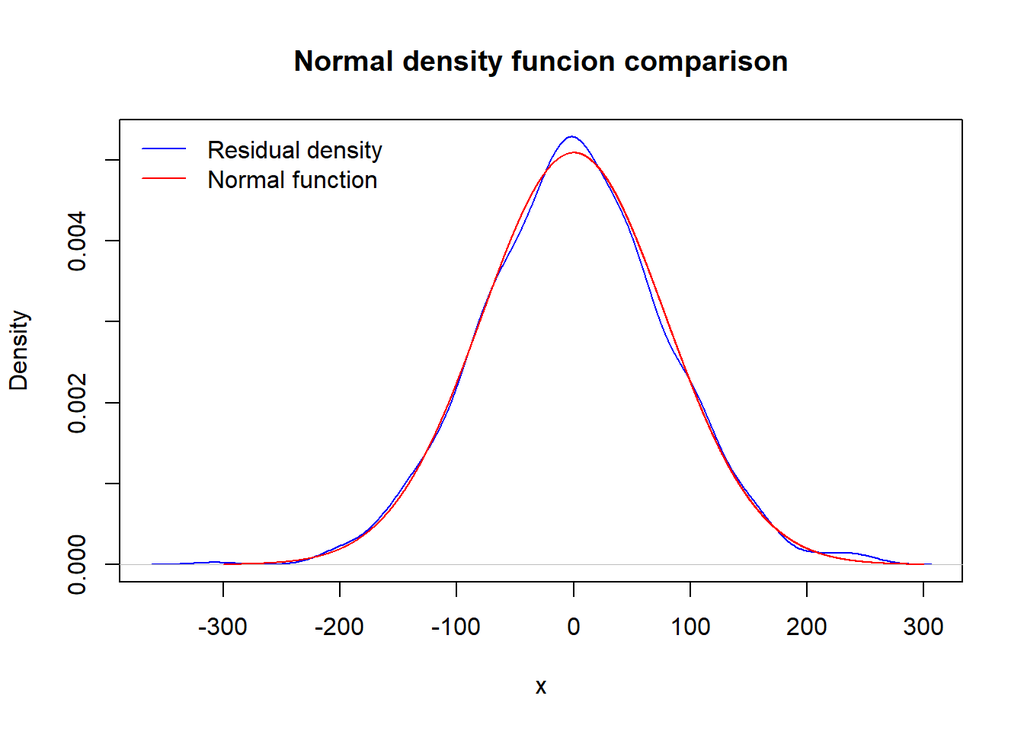

```
## [1] "Tudi z grafa je očitno, da gre za normalno porazdelitev."
```

##### Oglejte si ostanke po vašem modelu in komentirajte, ali so videti kot beli šum. Primerjajte njihovo porazdelitev z normalno.

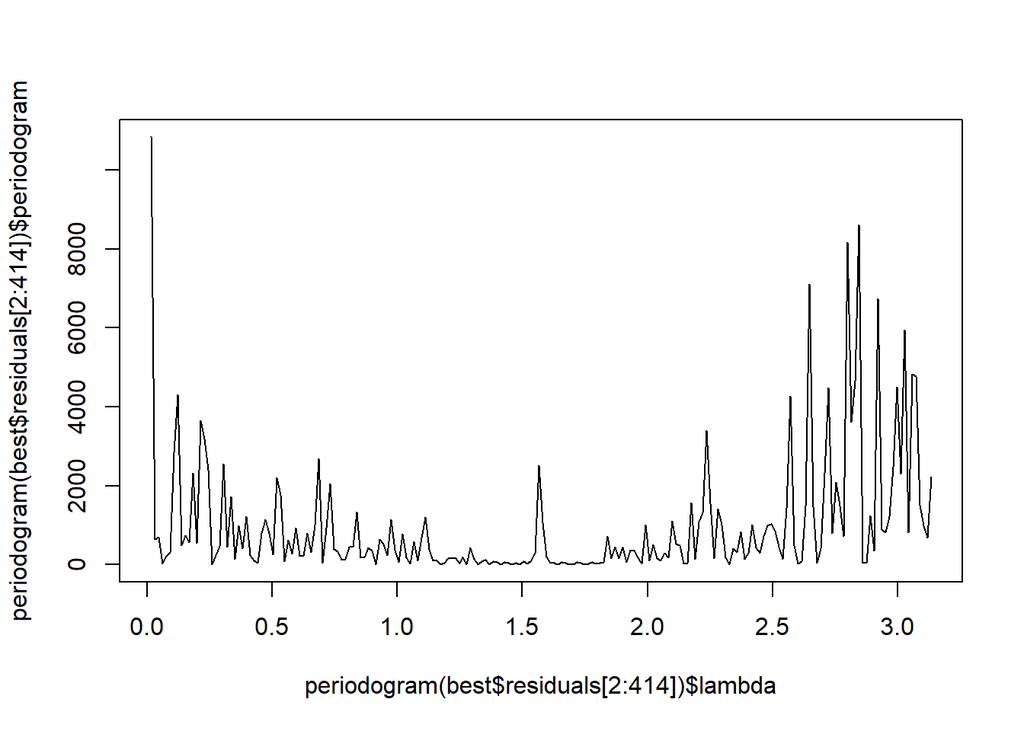

```
##
##  Box-Pierce test
##
## data:  x.res
## X-squared = 0.10129, df = 1, p-value = 0.7503
```

[output not shown]

```
##
##  Box-Ljung test
##
## data:  x.res
## X-squared = 0.10166, df = 1, p-value = 0.7498
```

[output not shown]

##### Z uporabo izbranega modela in pod predpostavko normalnosti z R-ovo funkcijo predict konstruirajte 90% napovedni interval za naslednjo vrednost. Ne pozabite vračunati tudi odstranjenega trenda in sezonskosti.

```
## [1] "Vrednost naslednjega člena v napovedi = 501.4451."
```

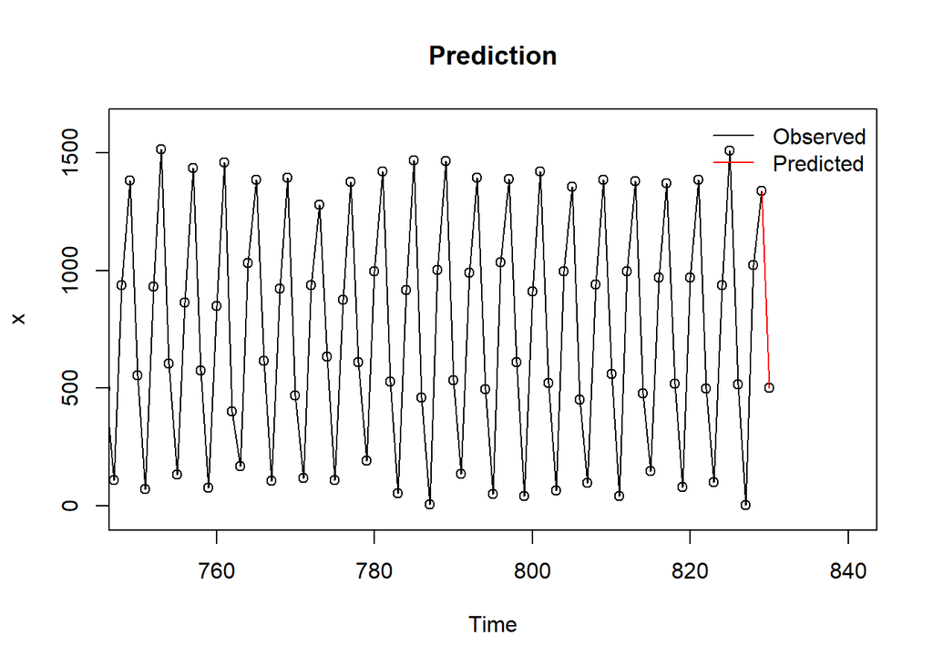

##### Dobljeni napovedni interval primerjajte z napovednim intervalom, ki bi ga dobili, če bi naivno privzeli, da so podatki kar Gaussov beli šum – pred in po odstranitvi trenda in sezonskosti.

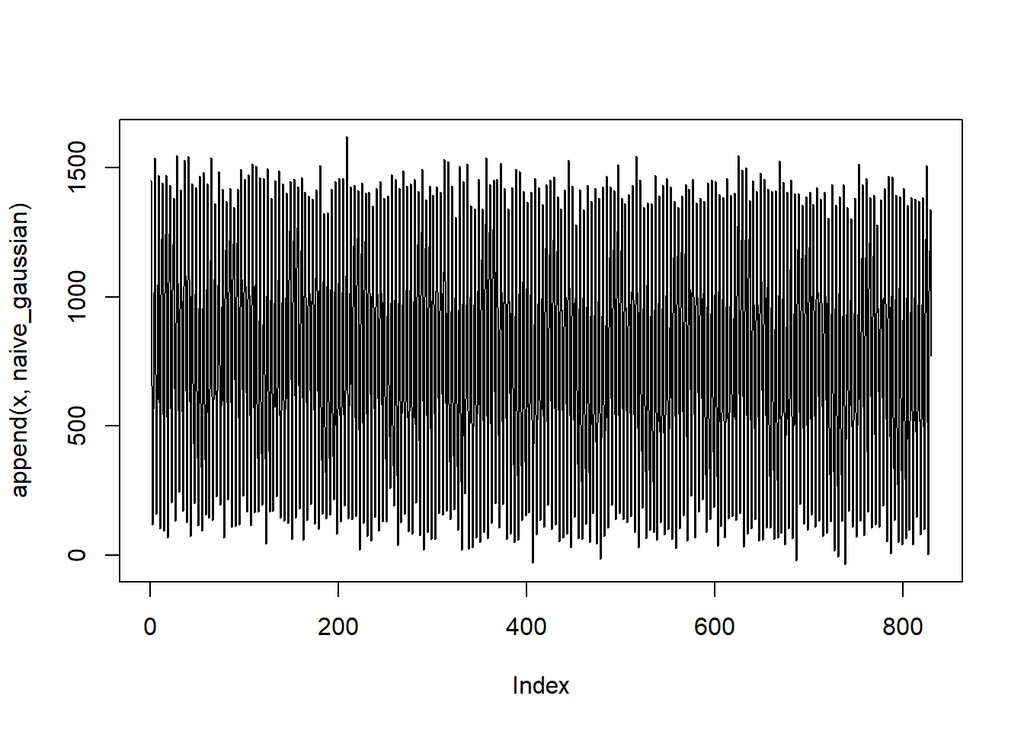

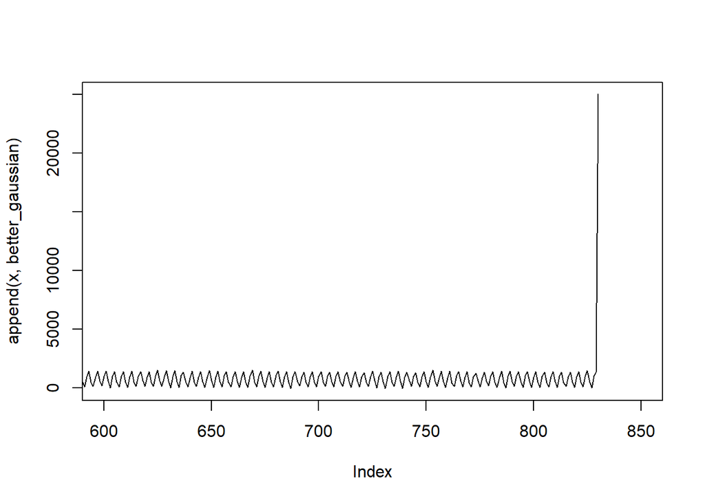

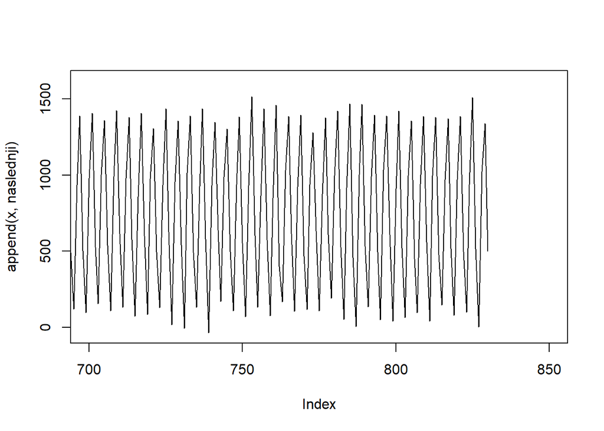

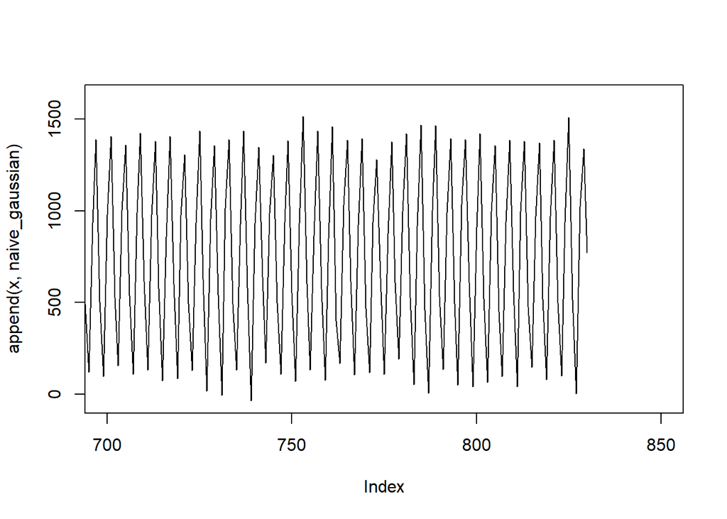

# DATOTEKA B

##### *Narišite graf in komentirajte, ali se iz njega vidi kakšen trend ali sezonskost.*

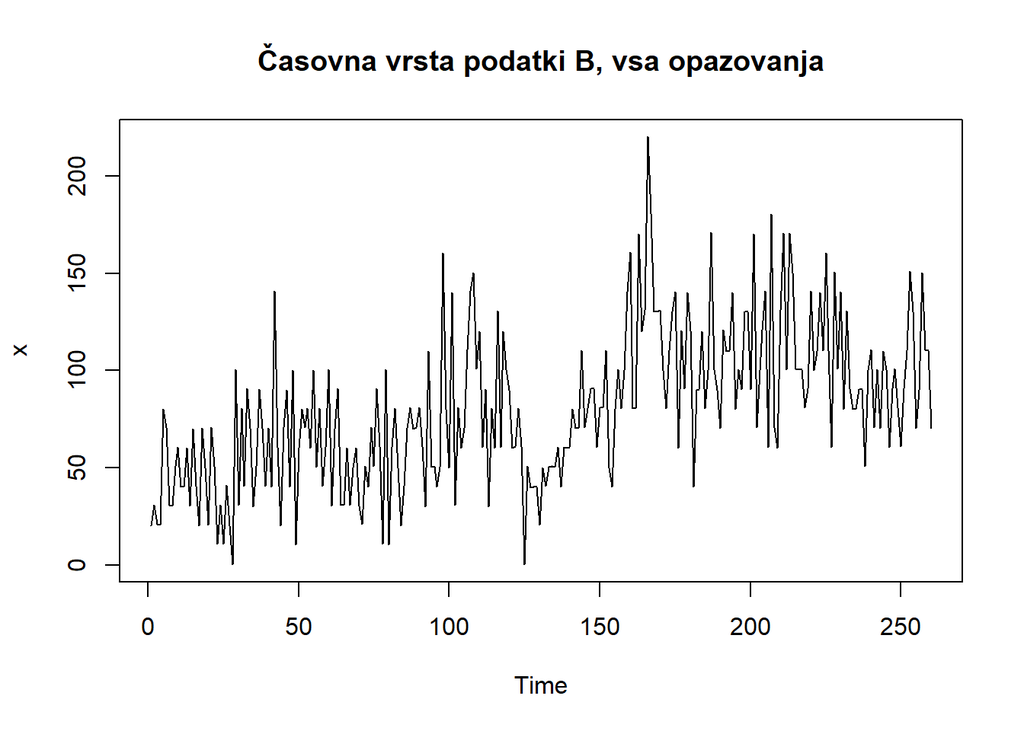

```
## [1] "Opazimo trend, na prvi pogled ne opazimo sezonskosti."
```

##### *Odstranite morebiten trend in sezonskost z metodami, uporabljenimi pri tečaju: (zaporedno) diferenciranje, logaritmiranje, neposredna ocena sezonskih komponent, polinomski trend stopnje največ 3 ali prileganje periodične funkcije (ali kakšna kombinacija teh metod). Potem ko odstranite morebiten trend, narišite tudi surovi in zglajeni periodogram ter komentirajte, ali se vidi kakšna sezonskost in kakšna naj bi bila perioda.*

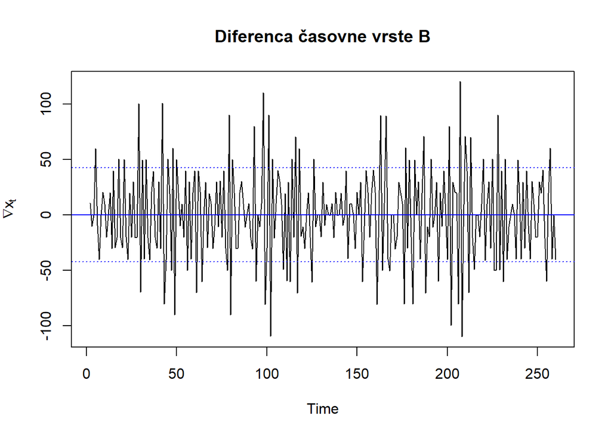

```
##
## Call:
## lm(formula = d ~ t)
##
## Residuals:
##      Min       1Q   Median       3Q      Max
## -109.586  -30.242    0.115   29.316  120.467
##
## Coefficients:
##              Estimate Std. Error t value Pr(>|t|)
## (Intercept)  1.020147   5.303022   0.192    0.848
## t           -0.006315   0.035158  -0.180    0.858
##
## Residual standard error: 42.3 on 257 degrees of freedom
## Multiple R-squared:  0.0001255,  Adjusted R-squared:  -0.003765
## F-statistic: 0.03226 on 1 and 257 DF,  p-value: 0.8576
```

```
##
## Call:
## lm(formula = d ~ I(sin(perioda * t)) + I(cos(perioda * t)) +
##     I(sin(perioda2 * t)))
##
## Residuals:
##      Min       1Q   Median       3Q      Max
## -129.473  -25.364   -1.095   25.456  127.129
##
## Coefficients:
##                      Estimate Std. Error t value Pr(>|t|)
## (Intercept)            0.1929     2.4665   0.078 0.937725
## I(sin(perioda * t))  -13.5722     3.4882  -3.891 0.000128 ***
## I(cos(perioda * t))   11.0090     3.4882   3.156 0.001791 **
## I(sin(perioda2 * t))  11.9987     3.4882   3.440 0.000680 ***
## ---
## Signif. codes:  0 '***' 0.001 '**' 0.01 '*' 0.05 '.' 0.1 ' ' 1
##
## Residual standard error: 39.69 on 255 degrees of freedom
## Multiple R-squared:  0.1265, Adjusted R-squared:  0.1162
## F-statistic: 12.31 on 3 and 255 DF,  p-value: 1.51e-07
```

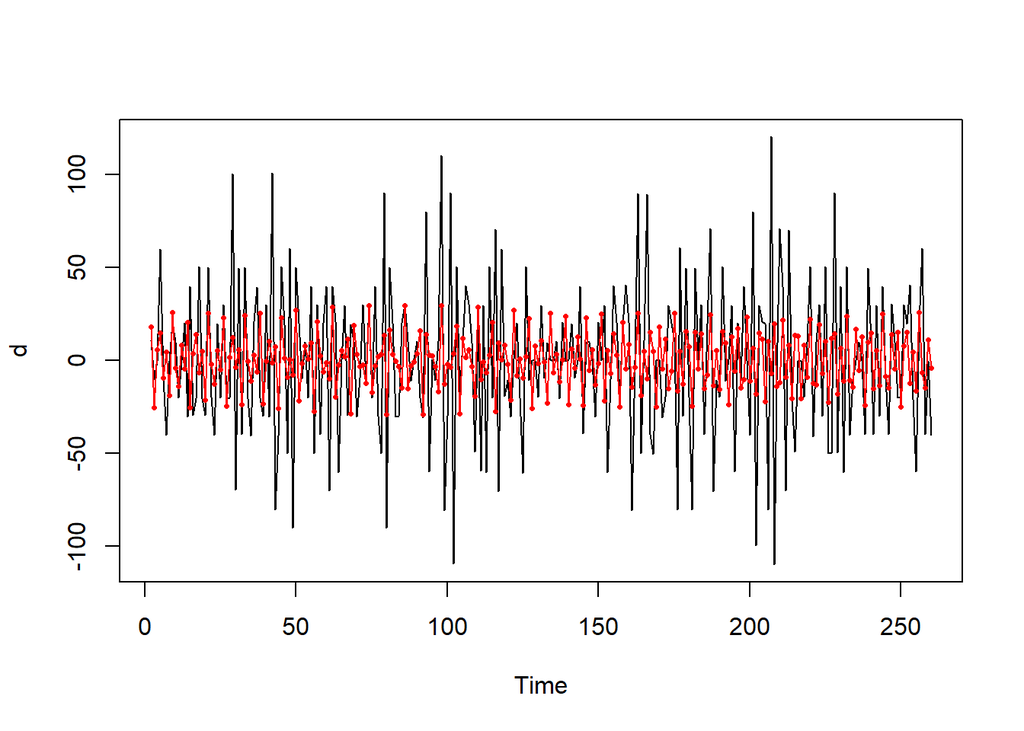

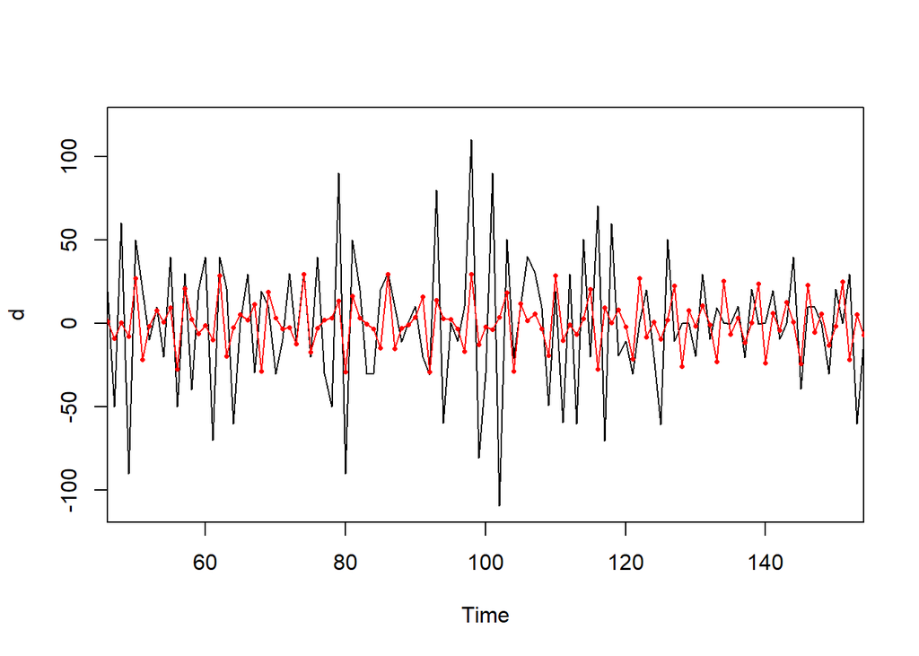

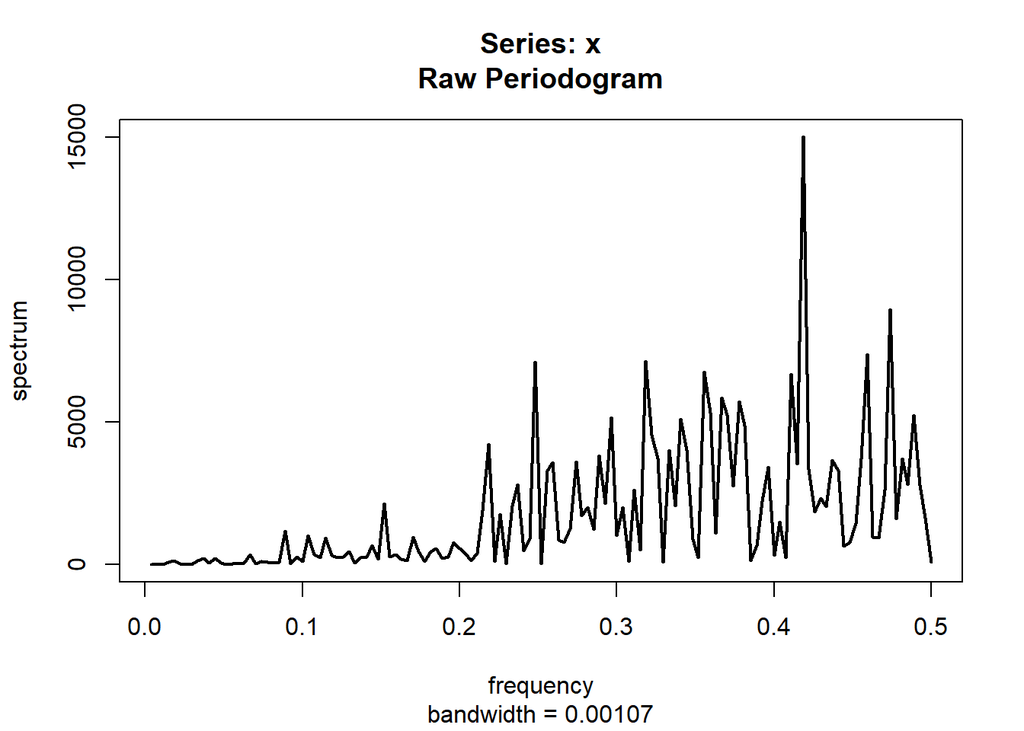

```
## Daniell(2)
## coef[-2] = 0.2
## coef[-1] = 0.2
## coef[ 0] = 0.2
## coef[ 1] = 0.2
## coef[ 2] = 0.2
```

```
## mDaniell(1)
## coef[-1] = 0.25
## coef[ 0] = 0.50
## coef[ 1] = 0.25
```

```
## Daniell(1,1)
## coef[-2] = 0.1111
## coef[-1] = 0.2222
## coef[ 0] = 0.3333
## coef[ 1] = 0.2222
## coef[ 2] = 0.1111
```

```
## mDaniell(1,1)
## coef[-2] = 0.0625
## coef[-1] = 0.2500
## coef[ 0] = 0.3750
## coef[ 1] = 0.2500
## coef[ 2] = 0.0625
```

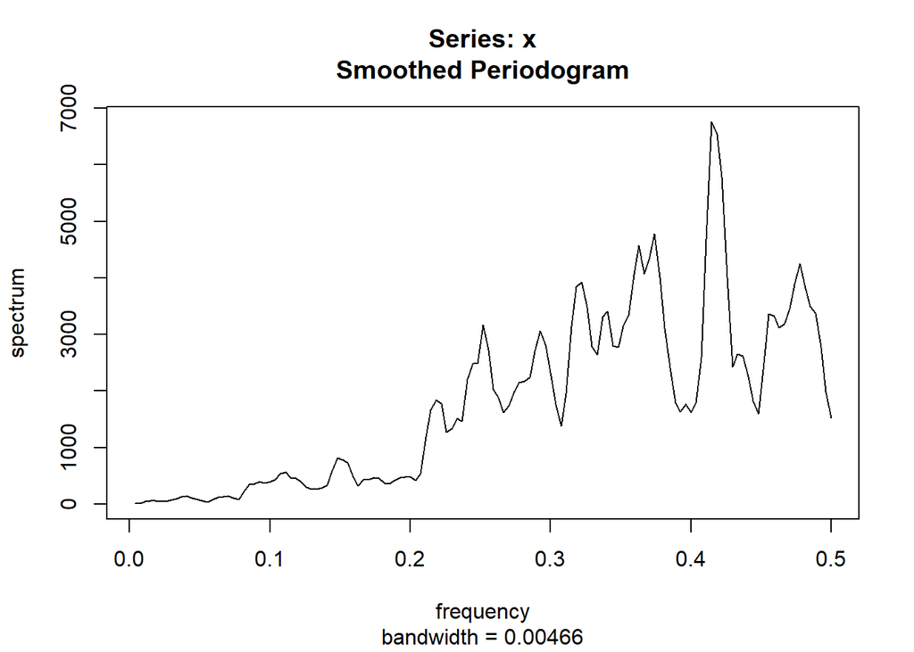

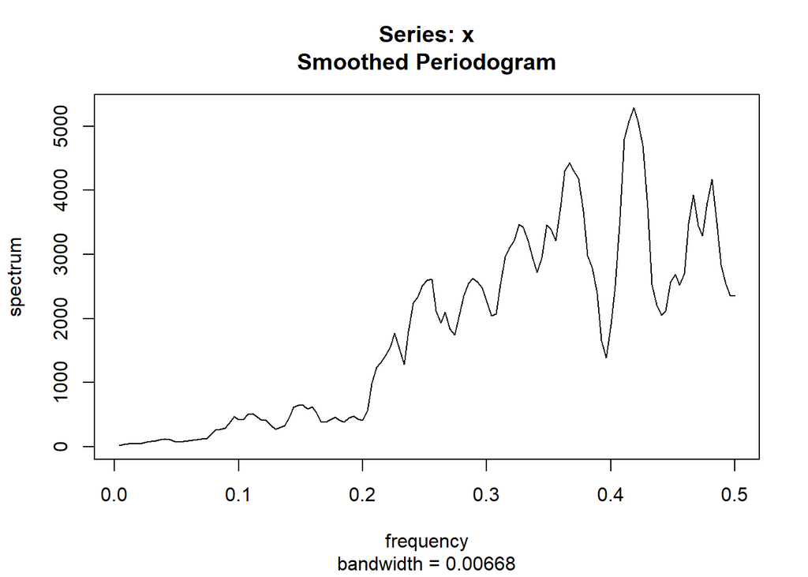

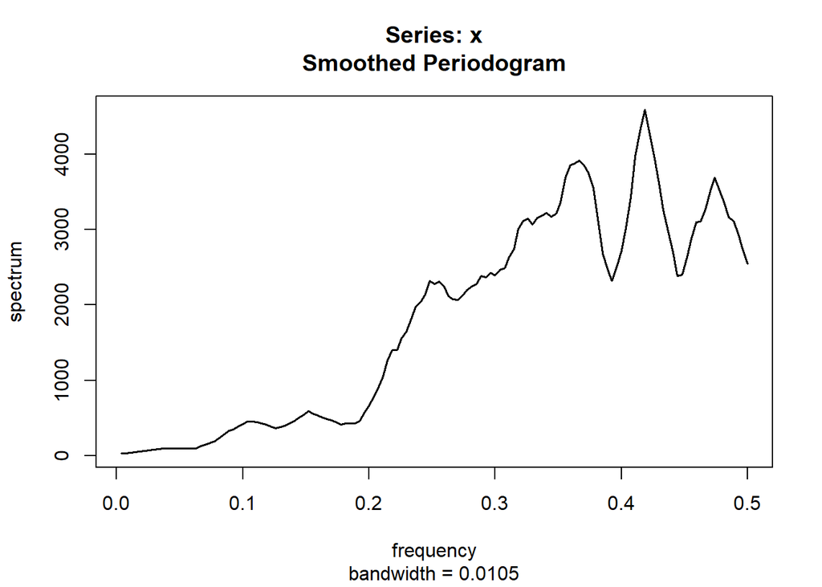

```
##   [1] 113 114 112 115 111  99  98 100  97 101  96 128 116 102 129 127 110  95
##  [19] 130 126 117  92  94  91  93 131  90  88 103 132  87 125 124  89 109  86
##  [37] 118 133 123  85 134 108 119 104  84 122 135 107  83 105  82  80 121  81
##  [55]  78 120  79 106  67  69  68  77  70  76  75  66  74  71  72  73  65  64
##  [73]  63  62  61  59  60  58  57  56  55  54  41  53  42  40  43  44  39  45
##  [91]  46  38  52  29  28  30  47  31  50  37  51  49  27  48  32  36  33  26
## [109]  35  34  25  24  23  22  21  20  19  18  17  12  13  16  10  15  14  11
## [127]   9   8   7   6   5   4   3   2   1
```

```
## [1] 0.4185185 0.4222222 0.4148148 0.4259259 0.4111111
```

```
## [1] 2.389381 2.368421 2.410714 2.347826 2.432432
```

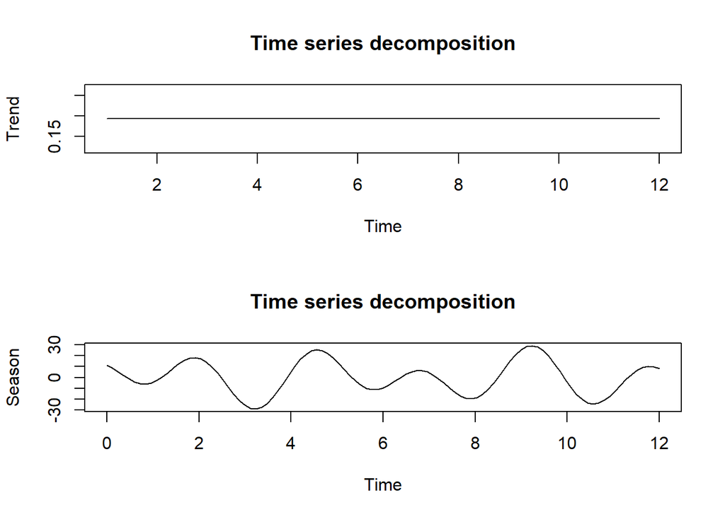

3. *Narišite graf rezidualov in komentirajte, ali so videti stacionarni. Stacionarnost tudi preizkusite z uporabo ustreznih statističnih metod.*

```
## [1] 0.1162349
```

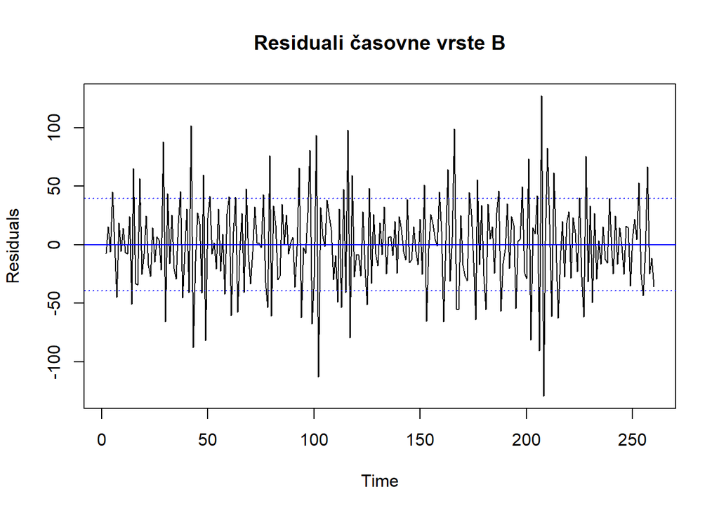

```
##
##  Augmented Dickey-Fuller Test
##
## data:  d.res
## Dickey-Fuller = -9.8487, Lag order = 6, p-value = 0.01
## alternative hypothesis: stationary
```

```
## [1] "Augmented Dickey-Fuller Test zavrne hipotezo, torej imamo stacionarnost."
```

4. *Na rezidualih naredite grafikona ACF in PACF in na njuni podlagi predlagajte vsaj en model vrste AR(p) ali MA(q).*

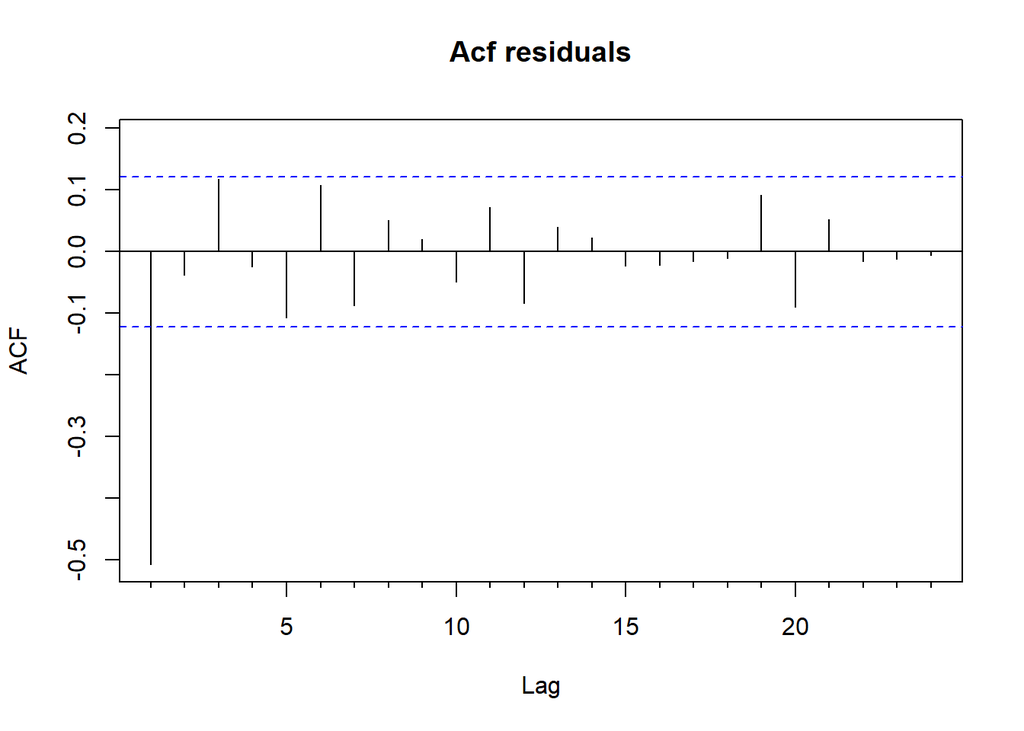

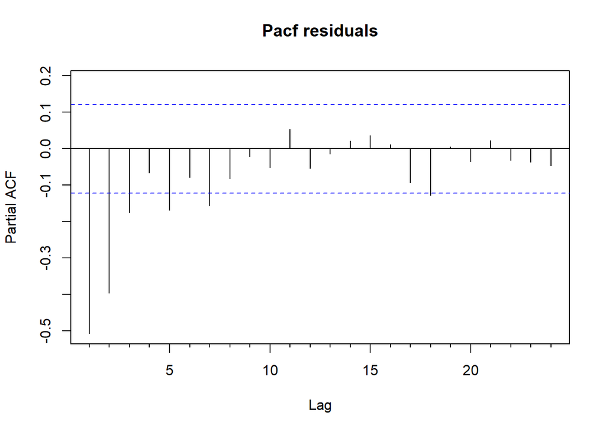

```
## [1] "Videti je, da imamo model MA(1)."
```

5. *Na podlagi Yule–Walkerjevih cenilk in kriterija AIC izberite najboljši model AR(p). Primerjajte ga z najboljšim modelom ARMA(p, q) za p + q ≤ 3 po kriteriju AIC (pozor: kriterij AIC je lahko definiran drugače od postopka do postopka). Če je videti smiselno, pa namesto tega uporabite model GARCH.*

```
##
## Call:
## arima(x = d.res, order = c(0, 0, 1))
##
## Coefficients:
##           ma1  intercept
##       -0.8230     0.0694
## s.e.   0.0373     0.3347
##
## sigma^2 estimated as 892:  log likelihood = -1247.83,  aic = 2501.66
```

```
## [1] 2641.848    0.000    0.000
## [1] 2501.655    0.000    1.000
## [1] 2503.039    0.000    2.000
## [1] 2504.986    0.000    3.000
## [1] 2566.877    1.000    0.000
## [1] 2503.076    1.000    1.000
## [1] 2505.03    1.00    2.00
## [1] 2506.516    1.000    3.000
## [1] 2524.164    2.000    0.000
## [1] 2504.782    2.000    1.000
## [1] 2506.134    2.000    2.000
## [1] 2505.88    2.00    3.00
## [1] 2517.258    3.000    0.000
## [1] 2501.527    3.000    1.000
## [1] 2501.342    3.000    2.000
## [1] 2506.387    3.000    3.000
```

```
## [1] "Algoritem vrne predlog za model MA(1)."
```

6. *Izberite »optimalni« model in ocenite vse njegove parametre.*

```
## [1] "OPTIMALNI MODEL: izberemo tisti model, ki ima najnižji aic. V najinem primeru je to MA(1)."
```

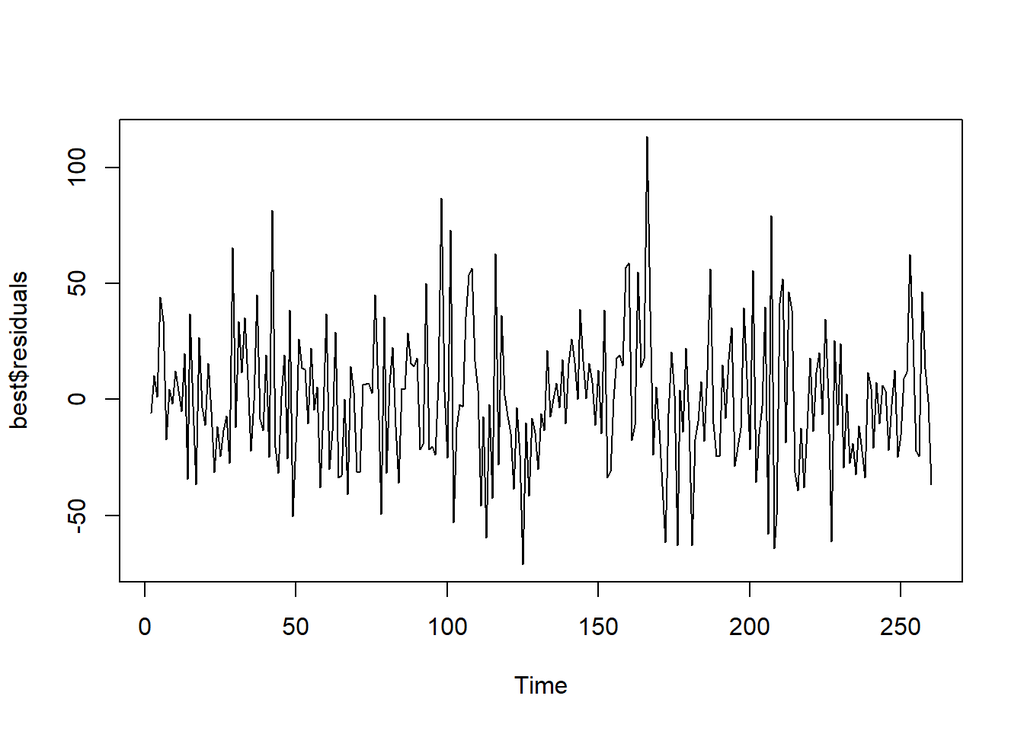

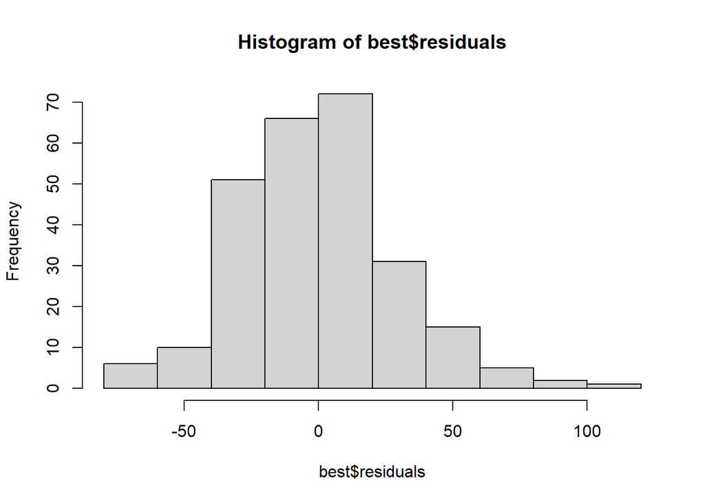

```
##
##  Shapiro-Wilk normality test
##
## data:  best$residuals
## W = 0.98559, p-value = 0.01039
```

[output not shown]

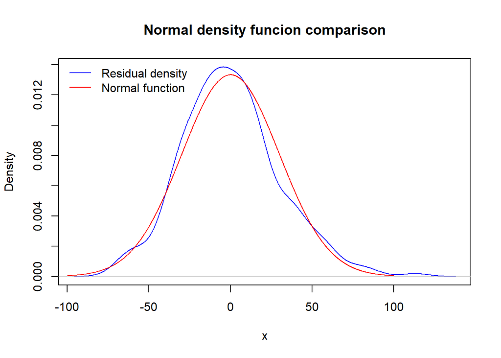

[output not shown]

7. *Oglejte si ostanke po vašem modelu in komentirajte, ali so videti kot beli šum. Primerjajte njihovo porazdelitev z normalno.*

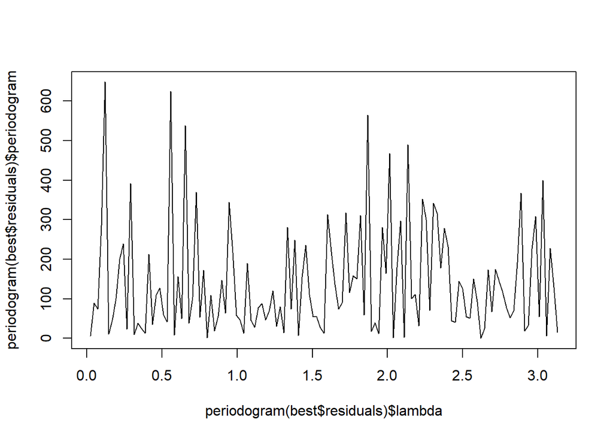

```
##
##  Box-Pierce test
##
## data:  d.res
## X-squared = 66.586, df = 1, p-value = 3.331e-16
```

```
## [1] "Box-Pierceov test zavrne hipotezo, torej ne gre za beli šum."
```

```
##
##  Box-Ljung test
##
## data:  d.res
## X-squared = 67.36, df = 1, p-value = 2.22e-16
```

```
## [1] "Ljung-Boxov test prav tako zavrne hipotezo, ne gre za beli šum."
```

8. *Z uporabo izbranega modela in pod predpostavko normalnosti z R-ovo funkcijo predict konstruirajte 90% napovedni interval za naslednjo vrednost. Ne pozabite vračunati tudi odstranjenega trenda in sezonskosti.*

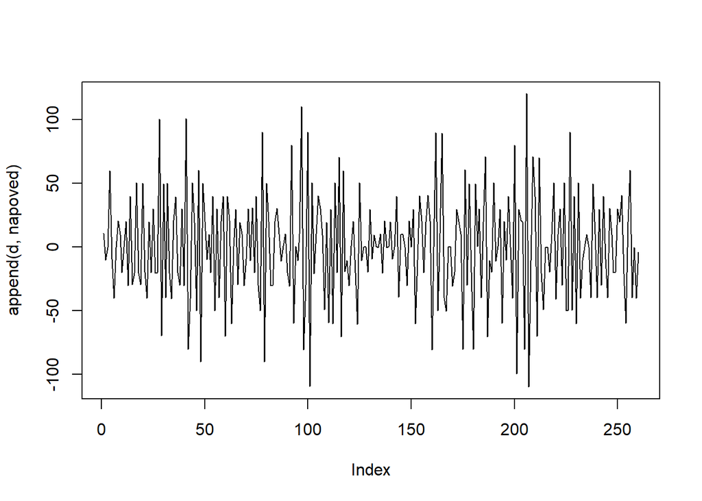

```
## [1] "Vrednost naslednjega člena v napovedi = 96.32199."
```

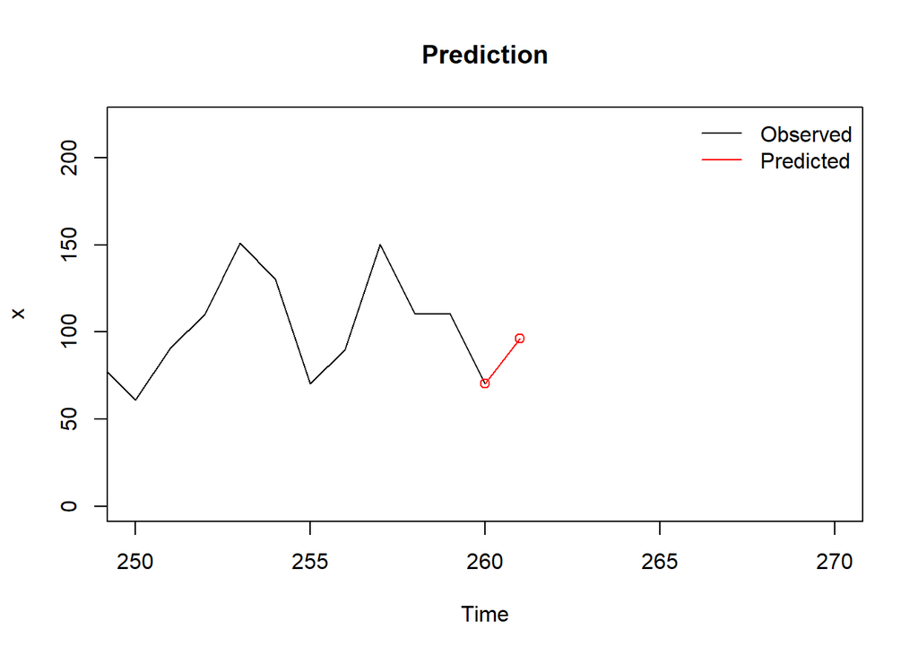

9. *Dobljeni napovedni interval primerjajte z napovednim intervalom, ki bi ga dobili, če bi naivno privzeli, da so podatki kar Gaussov beli šum – pred in po odstranitvi trenda in sezonskosti.*

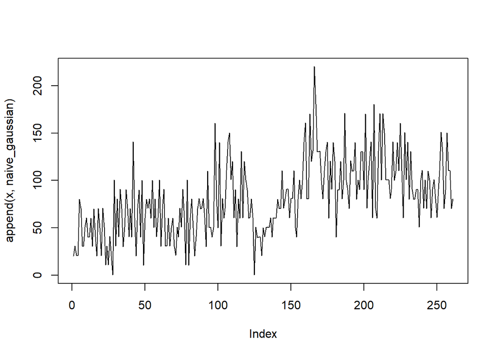

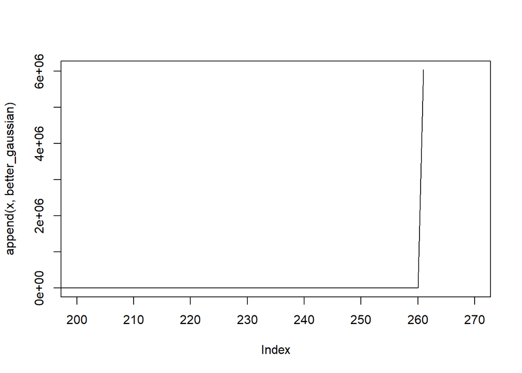

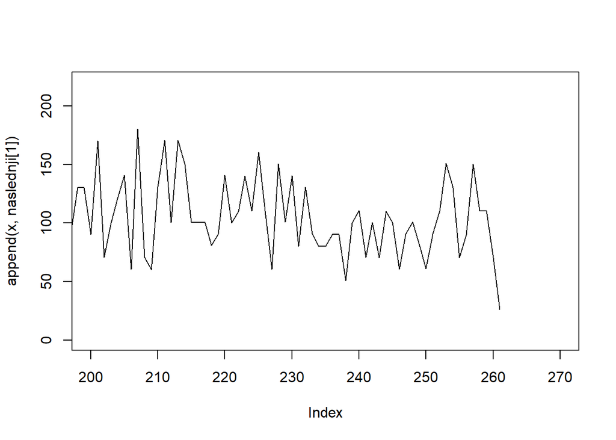

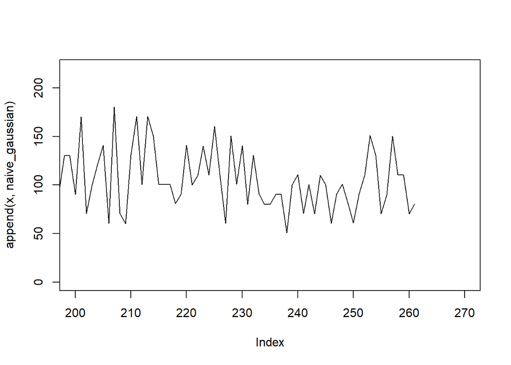

```
## [1] "Več komentarjev in opomb lahko najdete v Rmd datoteki."
```